# index

Author

Liz Loutrage

# Data load & preparation

```r
# Library ----
library(tidyr)
library(dplyr)
library(ggplot2)

# Isotopic data set ----
# DOI and reference : https://doi.org/10.48579/PRO/QE2VWQ

isotopic_dataset <-
  readxl::read_excel(here::here(
    "data",
    "C_N_isotopes_mesopelagic_2007-2021_BayofBiscay.xlsx"
  ),
  3) %>%
  # rename columns for simplicity
  rename(trawling_depth = `Trawling depth [m]`,
         size = `Standard length [cm] (individuals, mean)`,
         species = Taxa)%>%
  # create d15N column, when d15N untreated unavailable we take d15N cyclohexane-delipidated
  mutate(d15N= coalesce(`δ15N (untreated)`,`δ15N (cyclohexane-delipidated)`))

# Trawling data set ----
# DOI and reference : https://doi.org/10.48579/PRO/O5QHTE

trawling_dataset <-
  readxl::read_excel(here::here(
    "data",
    "Length_depth_distributions_mesopelagic_2011-2021_BayofBiscay.xlsx"
  ),
  3) %>%
  # rename columns for simplicity
  rename(trawling_depth = `Trawling depth [m]`,
         size = `Total length [cm]`,
         species = Species)%>%
  # add column with depth layer (cf Loutrage et al., 2023, DOI : 10.1016/j.pocean.2023.103070)
  mutate(
    depth_layer = case_when(
      between(trawling_depth, 0, 174) ~ "Epipelagic",
      between(trawling_depth, 175, 699) ~ "Upper mesopelagic",
      between(trawling_depth, 700, 999) ~ "Lower mesopelagic",
      between(trawling_depth, 1000, 2000) ~ "Bathypelagic")) %>%
  mutate(across(depth_layer, factor, levels = c("Epipelagic", "Upper mesopelagic", "Lower mesopelagic", "Bathypelagic")))
```

# 1. Relationships between size and depth

## Community level

- Bigger fish at depth?

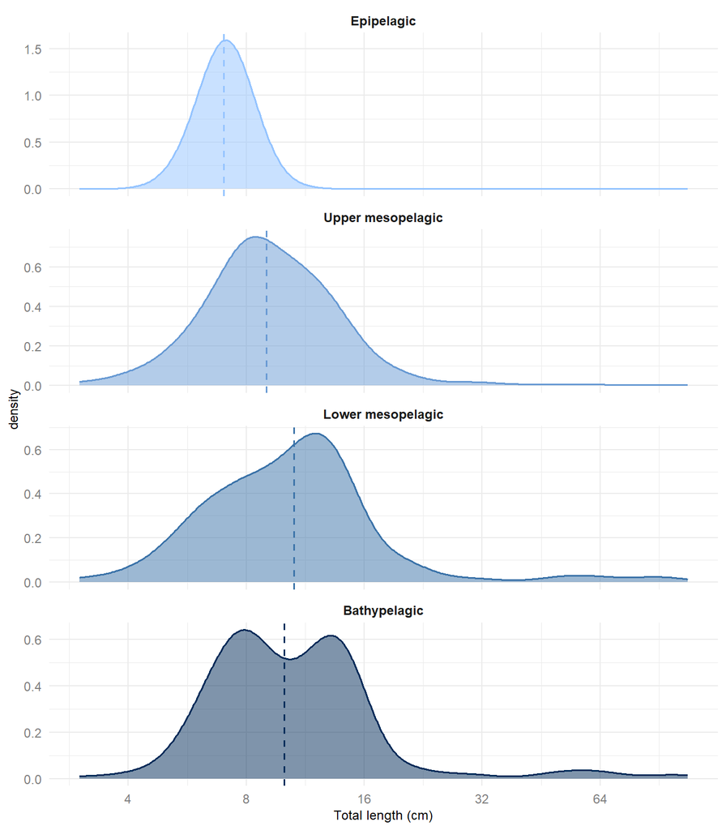

```r
# median size in each depth layer
median_size_data <- trawling_dataset %>%
  group_by(depth_layer) %>%
  summarise(median_size = median(size)) %>%
  mutate(across(
    depth_layer,
    factor,
    levels = c(
      "Epipelagic",
      "Upper mesopelagic",
      "Lower mesopelagic",
      "Bathypelagic"
    )
  ))

# plot
ggplot(trawling_dataset, aes(x = size)) +
  geom_density(
    alpha = 0.5,
    linewidth = 0.6,
    bw = 0.2,
    aes(col = depth_layer, fill = depth_layer)) +
  scale_fill_manual(values = c("#93C3FF", "#6799D3", "#3A72A8", "#002A58")) +
  scale_color_manual(values = c("#93C3FF", "#6799D3", "#3A72A8", "#002A58")) +
  facet_wrap( ~ depth_layer, ncol = 1, scales = "free_y") +
  theme_minimal() +
  scale_x_continuous(trans = 'log2') +
  theme(
    strip.text.x = element_text(size = 9, face = "bold"),
    strip.text.y = element_text(size = 9),
    axis.title = element_text(size = 9),
    axis.text =  element_text(size = 9, color = "grey50"),
    panel.background = element_rect(color = "white"),
    plot.background = element_rect(color = "white"),
    legend.title = element_text(size = 9),
    legend.text = element_text(size = 9)) +
  guides(fill = "none", col = "none") +
  xlab("Total length (cm)") +
  geom_vline(
    data = median_size_data,
    aes(xintercept = median_size, color = depth_layer),
    linewidth = 0.6,
    linetype = "dashed")
```

```r
# store the plot in the "figures" file in high resolution
ggsave("density_plot_community.png", path = "figures", dpi = 700, height = 6, width = 6)
```

### Linear relationship

```r
lr_size_depth_community <- trawling_dataset %>%
  do(broom::tidy(lm(size ~ trawling_depth, .))) %>%
  mutate(across(where(is.numeric), round, 2))

htmltools::tagList(DT::datatable(lr_size_depth_community))
```

|  | term | estimate | std.error | statistic | p.value |
| --- | --- | --- | --- | --- | --- |
| 1 | (Intercept) | 8.91 | 0.4 | 22.4 | 0 |
| 2 | trawling_depth | 0 | 0 | 7.34 | 0 |

## Species level

### Linear relationships

```r
lr_size_depth_sp <- trawling_dataset %>%
  group_by(species) %>%
  do(broom::tidy(lm(size ~ trawling_depth, .))) %>%
  mutate(across(where(is.numeric), round, 2))

htmltools::tagList(DT::datatable(lr_size_depth_sp))
```

|  | species | term | estimate | std.error | statistic | p.value |
| --- | --- | --- | --- | --- | --- | --- |
| 1 | Aphanopus carbo | (Intercept) | 75.64 | 8.32 | 9.09 | 0 |
| 2 | Aphanopus carbo | trawling_depth | 0.01 | 0.01 | 1.53 | 0.14 |
| 3 | Arctozenus risso | (Intercept) | 17.54 | 0.5 | 34.75 | 0 |
| 4 | Arctozenus risso | trawling_depth | 0 | 0 | -1.21 | 0.23 |
| 5 | Argyropelecus olfersii | (Intercept) | 6.7 | 0.29 | 22.99 | 0 |
| 6 | Argyropelecus olfersii | trawling_depth | 0 | 0 | 0.38 | 0.71 |
| 7 | Lampanyctus crocodilus | (Intercept) | 9.6 | 0.19 | 50.14 | 0 |
| 8 | Lampanyctus crocodilus | trawling_depth | 0 | 0 | 7.92 | 0 |
| 9 | Lampanyctus macdonaldi | (Intercept) | 14.12 | 0.56 | 25.12 | 0 |
| 10 | Lampanyctus macdonaldi | trawling_depth | 0 | 0 | 0.52 | 0.61 |

[output cut: 14 more lines]

### Density plot for significant relationships at the species level

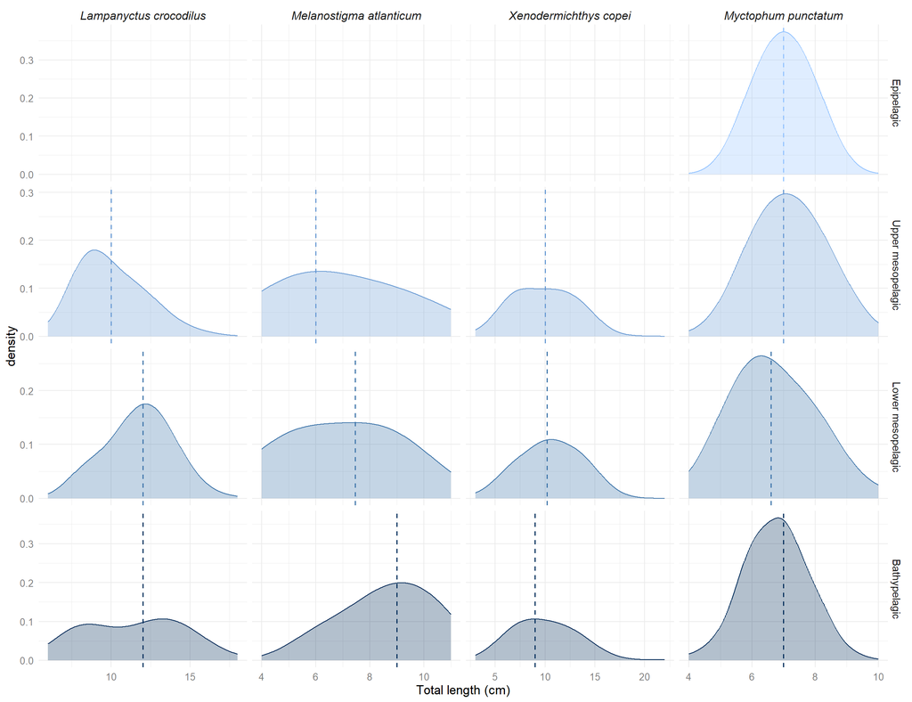

```r
# selection of species with a significant size-depth relationship (from linear models)

trawling_dataset_significant <- filter(trawling_dataset,
                                    species %in% c("Lampanyctus crocodilus","Melanostigma atlanticum",
                                                   "Xenodermichthys copei","Myctophum punctatum"))

trawling_dataset_significant$species <- factor(trawling_dataset_significant$species,
                                    levels = c("Lampanyctus crocodilus",
                                             "Melanostigma atlanticum",
                                             "Xenodermichthys copei",
                                             "Myctophum punctatum"))

# Median depth
median_size_species <- trawling_dataset_significant %>%
  group_by(species, depth_layer) %>%
  summarise(median_size_sp = median(size))

# plot
ggplot(trawling_dataset_significant, aes(x=size)) +
  geom_density(alpha=0.3, linewidth=0.5, adjust= 2, aes(fill= depth_layer, col= depth_layer))+
  scale_fill_manual(values = c("#93C3FF", "#6799D3","#3A72A8", "#002A58"))+
  scale_color_manual(values = c("#93C3FF", "#6799D3","#3A72A8", "#002A58"))+
  facet_grid(depth_layer~species, scale="free")+
  theme_minimal()+
  theme(strip.text.x = element_text(size=12,face="italic"),
        strip.text.y = element_text(size=11),
        axis.title = element_text(size=13),
        axis.text =  element_text(size=10, color= "grey50"),
        panel.background=element_rect(color="white"),
        plot.background = element_rect(color = "white"),
        legend.title = element_text(size=10),
        legend.text = element_text(size=10))+
  guides(fill="none",col="none")+
  xlab("Total length (cm)")+
  geom_vline(data =median_size_species, aes(xintercept = median_size_sp, color=depth_layer),
             linewidth=0.6, linetype="dashed")
```

```r
# store the plot in the "figures" file in high resolution
ggsave("density_plot_species.png", path = "figures", dpi = 700, height = 7, width = 9)
```

# 2. $\delta$<sup>15</sup>N-size relationships

**Latitude-depth influence on $\delta$<sup>15</sup>N values** : as the sampling was carried out over a wide range of latitudes, we check that this has not had a significant influence on the $\delta$<sup>15</sup>N values using an analysis of variance (is it depth or latitude that has the greatest influence on these values?)

- No significant influence of latitude on $\delta$<sup>15</sup>N values

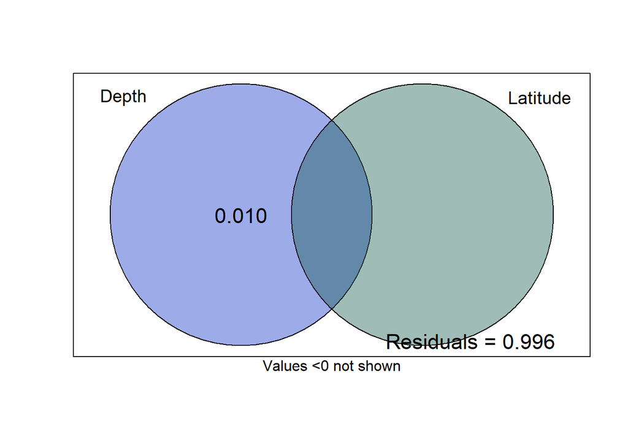

```r
isotopic_varpart <- isotopic_dataset%>%
  na.omit()

# Perform variation partitioning analysis
part <- vegan::varpart(isotopic_varpart$d15N,
                               ~ trawling_depth, ~ LatitudeEvent, data = isotopic_varpart)

# Create the specified plot for the current species
plot(
  part,
  Xnames = c("Depth", "Latitude"),
  # name the partitions
  bg = c("#072AC8", "#0B5345"),
  alpha = 100,
  # colour the circles
  digits = 2,
  # only show 2 digits
  cex = 1.4
)
```

```r
rda1 <- vegan::rda(isotopic_varpart$d15N,
                   isotopic_varpart$trawling_depth,
                   isotopic_varpart$LatitudeEvent)

rda2 <- vegan::rda(isotopic_varpart$d15N,
                   isotopic_varpart$LatitudeEvent,
                   isotopic_varpart$trawling_depth)

vegan::anova.cca(rda1)
```

```
Permutation test for rda under reduced model
Permutation: free
Number of permutations: 999

Model: rda(X = isotopic_varpart$d15N, Y = isotopic_varpart$trawling_depth, Z = isotopic_varpart$LatitudeEvent)
          Df Variance      F Pr(>F)
Model      1  0.01003 2.7091  0.094 .
Residual 172  0.63668
---
Signif. codes:  0 '***' 0.001 '**' 0.01 '*' 0.05 '.' 0.1 ' ' 1
```

```r
vegan::anova.cca(rda2)
```

```
Permutation test for rda under reduced model
Permutation: free
Number of permutations: 999

Model: rda(X = isotopic_varpart$d15N, Y = isotopic_varpart$LatitudeEvent, Z = isotopic_varpart$trawling_depth)
          Df Variance      F Pr(>F)
Model      1  0.00097 0.2614  0.621
Residual 172  0.63668
```

## At community level

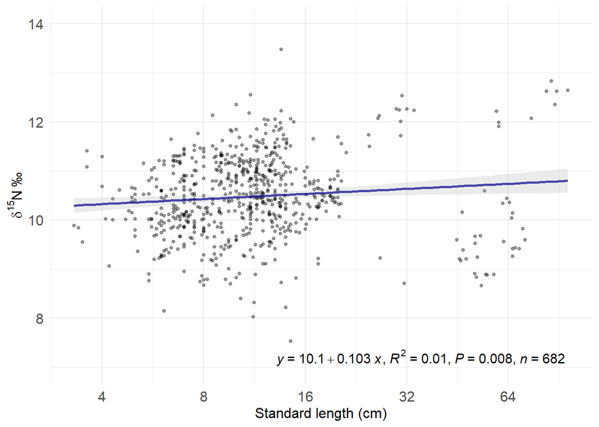

```r
# plot
ggplot(isotopic_dataset , aes(x=size, y=d15N))+
  geom_point (alpha=0.4, size=1) +
  geom_smooth(method=lm, se=T, alpha=0.2, col= alpha("darkblue",0.7)) +
  ggpmisc::stat_poly_eq(formula = y ~ x,
                        aes(label = paste(..eq.label.., ..rr.label.., ..p.value.label..
                                          , ..n.label..,sep = "*`,`~")),
                        parse = TRUE,
                        size=4,
                        label.x.npc = "right",
                        label.y.npc = "bottom",
                        vstep = -0.0005)+
  scale_x_continuous(trans = 'log2') +
  xlab("Standard length (cm)")+
  ylab(expression({delta}^15*N~'\u2030'))+
  ylim(c(7, 14))+
  guides(fill="none")+
  theme_minimal()+
  theme(strip.text.x = element_text(size=12,face="italic"),
        axis.title = element_text(size=12),
        axis.text =  element_text(size=12),
        plot.background = element_rect(colour = "white"))
```

```r
# store the plot in the "figures" file in high resolution
ggsave("d15n_size_community.png", path = "figures", dpi = 700)
```

## At species level

### Data summary

```r
data_sum <- isotopic_dataset %>%
  group_by(species) %>%
  summarise(
    range_size = max(size) - min(size),
    min_size = min(size),
    max_size = max(size),
    mean_size = mean(size),
    mean_d15n = mean(d15N),
    range_depth = max(trawling_depth) - min(trawling_depth)) %>%
  mutate(across(where(is.numeric), round, 2))

htmltools::tagList(DT::datatable(data_sum))
```

|  | species | range_size | min_size | max_size | mean_size | mean_d15n | range_depth |
| --- | --- | --- | --- | --- | --- | --- | --- |
| 1 | Aphanopus carbo | 37 | 59 | 96 | 77.33 | 12.36 | 30 |
| 2 | Arctozenus risso | 9.5 | 11 | 20.5 | 16.48 | 10.53 | 409 |
| 3 | Argyropelecus olfersii | 6.7 | 3.3 | 10 | 6.3 | 10.18 | 963 |
| 4 | Lampanyctus crocodilus | 8.3 | 6.5 | 14.8 | 10.95 | 10.46 | 1229 |
| 5 | Lampanyctus macdonaldi | 3.3 | 11.5 | 14.8 | 13.13 | 11.54 | 666 |
| 6 | Melanostigma atlanticum | 4 | 7 | 11 | 9.65 | 11.21 | 278 |
| 7 | Myctophum punctatum | 4 | 5 | 9 | 6.73 | 9.99 | 1309 |
| 8 | Notoscopelus kroyeri | 8.1 | 3.6 | 11.7 | 7.86 | 11.18 | 755 |
| 9 | Searsia koefoedi | 6 | 8.5 | 14.5 | 11.69 | 11.8 | 247 |
| 10 | Serrivomer beanii | 45 | 26.7 | 71.7 | 55.36 | 9.49 | 618 |

[output cut: 2 more lines]

### Linear relationships

#### Plot linear relationships

- **A**: significant relationships
- **B**: non-significant relationships

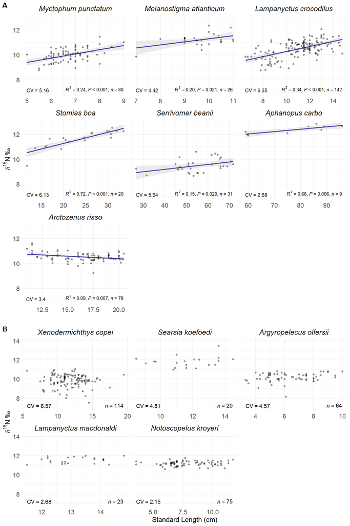

```r
# function to calculate coefficient of variation
cv <- function(x) {
  (sd(x) / mean(x)) * 100
}

# Selection of species presenting significant d15N-size relationship
ontogeny_significant <- filter(
  isotopic_dataset,
  species %in% c(
    "Lampanyctus crocodilus",
    "Aphanopus carbo",
    "Melanostigma atlanticum",
    "Serrivomer beanii",
    "Stomias boa",
    "Myctophum punctatum",
    "Arctozenus risso"
  )
)
# Order species
ontogeny_significant$species <- factor(
  ontogeny_significant$species,
  levels = c(
    "Myctophum punctatum",
    "Melanostigma atlanticum",
    "Lampanyctus crocodilus",
    "Stomias boa",
    "Serrivomer beanii",
    "Aphanopus carbo",
    "Arctozenus risso"
  )
)

# plot of significant relationships
coeff_var_s <- aggregate(d15N ~ species,
                       data = ontogeny_significant,
                       FUN = cv)
coeff_var_s$d15N <- round(coeff_var_s$d15N, digits = 2)

# plot of significant relationships
plot_significant <- ggplot(ontogeny_significant, aes(x=size, y=d15N))+
  geom_point (alpha=0.4, col="black") +
  geom_smooth(method=lm, se=T, alpha=0.2, col= alpha("darkblue",0.7)) +
  facet_wrap(~species, scale="free_x", ncol=3)+
  ggpmisc::stat_poly_eq(formula = y ~ x,
                        aes(label = paste(..rr.label.., ..p.value.label..
                                          , ..n.label..,sep = "*`,`~")),
                        parse = TRUE,
                        size=3.38,
                        label.x.npc = "right",
                        label.y.npc = "bottom",
                        vstep = -0.0005)+
  xlab("")+
  ylab(expression({delta}^15*N~'\u2030'))+
  ylim(c(7,13))+
  guides(color="none", fill="none")+
  theme_minimal()+
  theme(strip.text.x = element_text(size=15,face="italic"),
        plot.background = element_rect(colour = "white"),
        axis.title = element_text(size=14),
        axis.text =  element_text(size=13))+
  geom_text(coeff_var_s, mapping = aes(x = -Inf, y = -Inf, label = paste("CV = ", d15N, sep = "")),
            hjust = -0.2, vjust = -1, size = 3.5)

# Selection of species presenting non-significant d15N-size relationship
ontogeny_non_significant <- filter(isotopic_dataset,
                                   species %in% c("Argyropelecus olfersii", "Lampanyctus macdonaldi",
                                                  "Searsia koefoedi", "Notoscopelus kroyeri",
                                                  "Xenodermichthys copei"))

#order species
ontogeny_non_significant$species <- factor(ontogeny_non_significant$species,
                                           levels = c("Xenodermichthys copei",
                                                      "Searsia koefoedi",
                                                      "Argyropelecus olfersii",
                                                      "Lampanyctus macdonaldi",
                                                      "Notoscopelus kroyeri"))

coeff_var <- aggregate(d15N ~ species,
                       data = ontogeny_non_significant,
                       FUN = cv)
coeff_var$d15N <- round(coeff_var$d15N, digits = 2)


# plot of non-significant relationships
plot_non_significant <- ggplot(ontogeny_non_significant, aes(x=size, y=d15N))+
  geom_point (alpha=0.4, col="black") +
  facet_wrap(~species, scale="free_x", ncol=3, nrow = 3)+
  ggpmisc::stat_poly_eq(formula = y ~ x,
                        aes(label = paste( ..n.label..,sep = "*`,`~")),
                        parse = TRUE,
                        size=4,
                        label.x.npc = "right",
                        label.y.npc = "bottom",
                        vstep = -0.0005)+
  xlab("Standard Length (cm)")+
  ylab(expression({delta}^15*N~'\u2030'))+
  ylim(c(7, 14))+
  guides(color="none", fill="none")+
  theme_minimal()+
  theme(strip.text.x = element_text(size=15,face="italic"),
        axis.title = element_text(size=14),
        plot.background = element_rect(colour = "white"),
        axis.text =  element_text(size=13))+
  geom_text(coeff_var, mapping = aes(x = -Inf, y = -Inf, label = paste("CV = ", d15N, sep = "")),
            hjust = -0.2, vjust = -0.8, size = 4)

# Combine the two plots
ggpubr::ggarrange(
  plot_significant,
  plot_non_significant,
  ncol = 1,
  labels = c("A", "B"),
  heights = c(2, 1.25)
)
```

```r
# store the plot in the "figures" file in high resolution
ggsave("d15n_size_sp.png", path = "figures", dpi = 700, height = 15, width = 10)
```

#### Assumptions validation for linear models

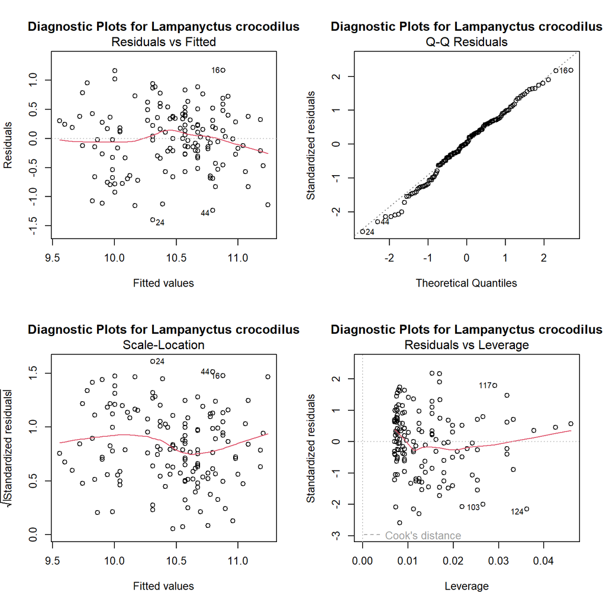

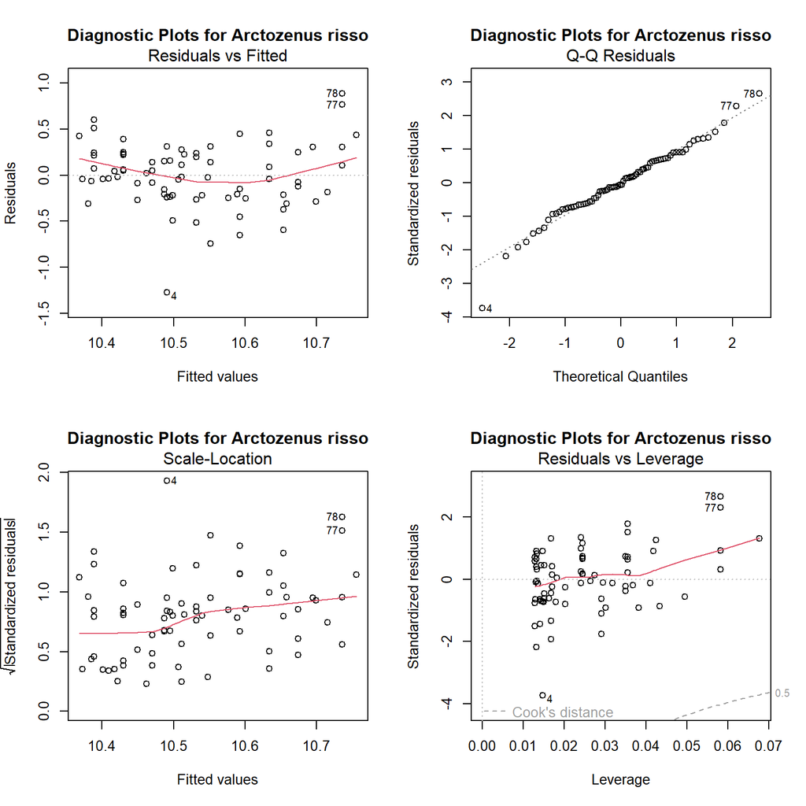

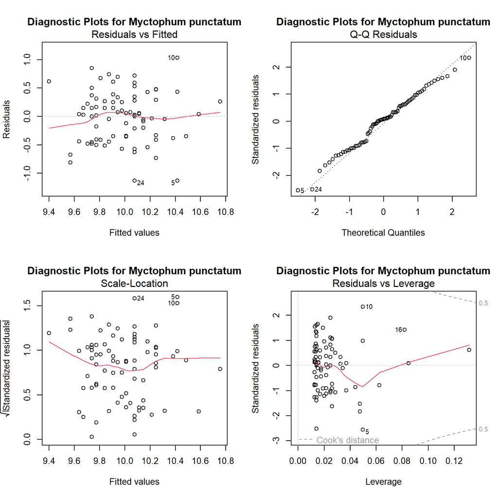

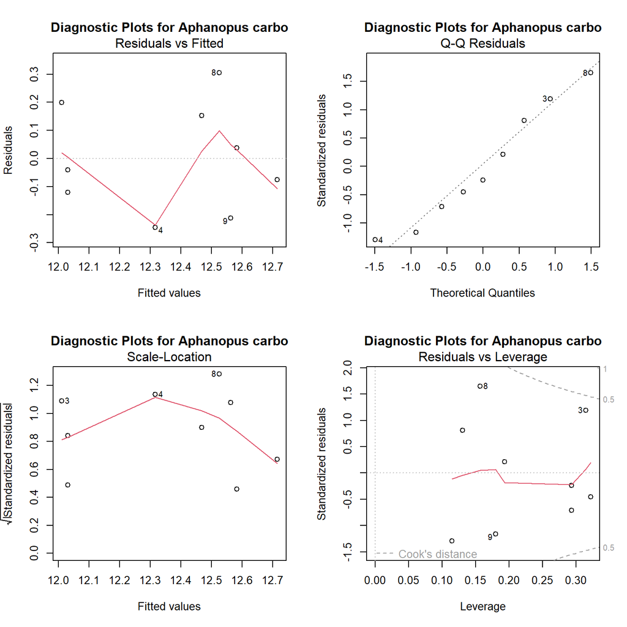

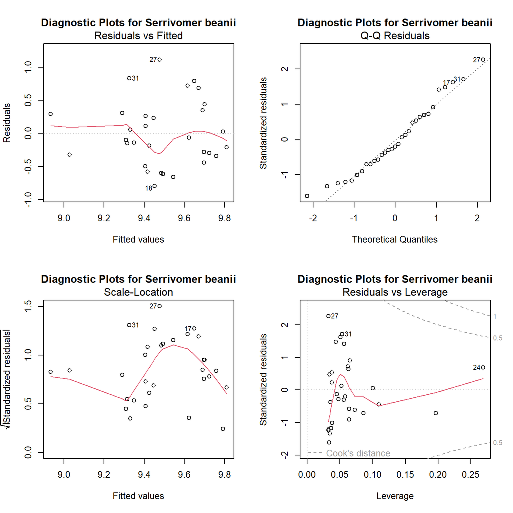

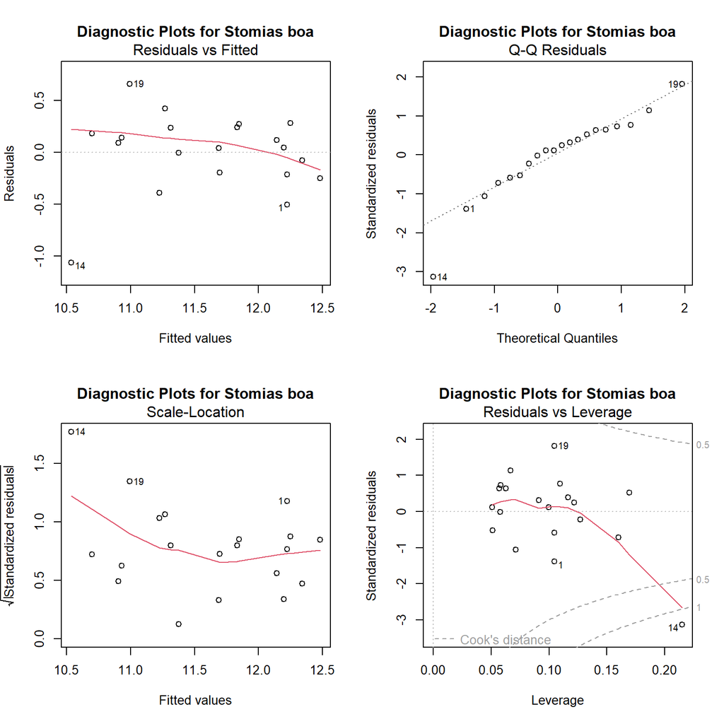

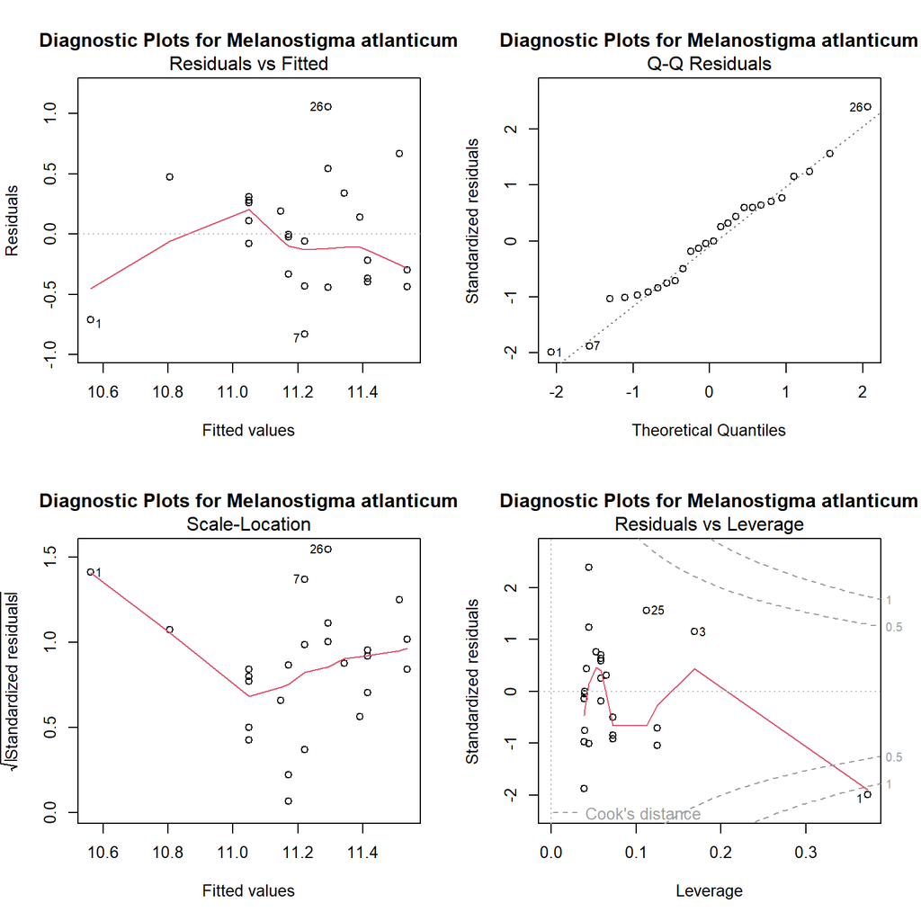

```r
# Create an empty list to store diagnostic metrics
diag_metrics_list <- list()

species_list <- unique(ontogeny_significant$species)

for (species_name in species_list){
  species_data <- ontogeny_significant %>%
    filter(species == species_name)

  # Fit the linear model
  model <- lm(d15N ~ size, data = species_data)

  # Create diagnostic plots
  par(mfrow = c(2, 2))
  plot(model, main = paste("Diagnostic Plots for", species_name))

  # Get diagnostic metrics and store them in the list
  model.diag.metrics <- broom::augment(model)
  diag_metrics_list[[species_name]] <- model.diag.metrics %>%
    top_n(3, wt = .cooksd)
}
```

**Access diagnostic metrics**

```r
print(diag_metrics_list)
```

```
$`Lampanyctus crocodilus`
# A tibble: 3 × 8
   d15N  size .fitted .resid   .hat .sigma .cooksd .std.resid
  <dbl> <dbl>   <dbl>  <dbl>  <dbl>  <dbl>   <dbl>      <dbl>
1  8.75   7.8    9.82 -1.07  0.0266  0.537  0.0547      -2.00
2 10.7    7.6    9.78  0.959 0.0291  0.538  0.0482       1.79
3 10.1   14.8   11.2  -1.14  0.0362  0.536  0.0865      -2.15

$`Arctozenus risso`
# A tibble: 3 × 8
   d15N  size .fitted .resid   .hat .sigma .cooksd .std.resid
  <dbl> <dbl>   <dbl>  <dbl>  <dbl>  <dbl>   <dbl>      <dbl>
1  9.22  17.5    10.5 -1.27  0.0147  0.312   0.104      -3.73
2 11.5   11.5    10.7  0.764 0.0582  0.333   0.163       2.30
3 11.6   11.5    10.7  0.884 0.0582  0.329   0.218       2.66

$`Myctophum punctatum`
# A tibble: 3 × 8
   d15N  size .fitted .resid   .hat .sigma .cooksd .std.resid
  <dbl> <dbl>   <dbl>  <dbl>  <dbl>  <dbl>   <dbl>      <dbl>
1  9.29     8   10.4  -1.13  0.0497  0.436  0.171       -2.56
2 11.4      8   10.4   1.03  0.0497  0.439  0.143        2.34
3 10.0      5    9.40  0.619 0.0818  0.450  0.0909       1.43

$`Aphanopus carbo`
# A tibble: 3 × 8
   d15N  size .fitted .resid  .hat .sigma .cooksd .std.resid
  <dbl> <dbl>   <dbl>  <dbl> <dbl>  <dbl>   <dbl>      <dbl>
1  12.2    59    12.0  0.199 0.315  0.195   0.326       1.19
2  12.8    86    12.5  0.305 0.157  0.170   0.252       1.65
3  12.4    88    12.6 -0.213 0.180  0.196   0.149      -1.17

$`Serrivomer beanii`
# A tibble: 3 × 8
   d15N  size .fitted .resid   .hat .sigma .cooksd .std.resid
  <dbl> <dbl>   <dbl>  <dbl>  <dbl>  <dbl>   <dbl>      <dbl>
1  9.23  26.7    8.93  0.295 0.269   0.505  0.0877      0.690
2 10.6   54.5    9.48  1.11  0.0325  0.462  0.0858      2.26
3 10.2   46.8    9.33  0.834 0.0534  0.483  0.0826      1.71

$`Stomias boa`
# A tibble: 3 × 8
   d15N  size .fitted .resid  .hat .sigma .cooksd .std.resid
  <dbl> <dbl>   <dbl>  <dbl> <dbl>  <dbl>   <dbl>      <dbl>
1 11.7   30.7    12.2 -0.504 0.105  0.373   0.112      -1.39
2  9.47  11.8    10.5 -1.07  0.215  0.266   1.35       -3.13
3 11.6   16.9    11.0  0.658 0.105  0.357   0.192       1.81

$`Melanostigma atlanticum`
# A tibble: 3 × 8
   d15N  size .fitted .resid  .hat .sigma .cooksd .std.resid
  <dbl> <dbl>   <dbl>  <dbl> <dbl>  <dbl>   <dbl>      <dbl>
1  9.85   7      10.6 -0.711 0.373  0.421   1.18       -1.99
2 11.3    8      10.8  0.474 0.169  0.448   0.135       1.15
3 12.2   10.9    11.5  0.666 0.112  0.437   0.155       1.57
```

# 3. Variation partitionning

- At the species level, is it the sampling depth or the size of the individuals that most influences the values in $\delta$<sup>15</sup>N?
- To test the significance of the influence of each variable (depth and size) on $\delta$<sup>15</sup>N values an ANOVA-type permutation test was performed for each model (anova.cca function)
- Since the third fraction (depth and size) is not the result of an RDA, it cannot be tested for significance.

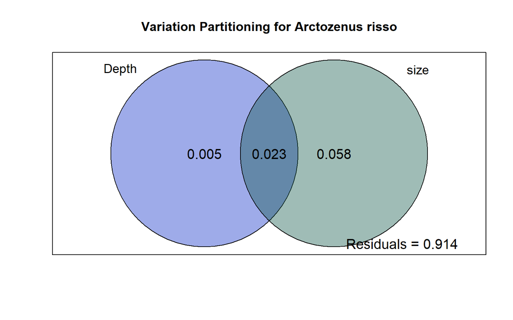

```
ANOVA (Depth-Size):
# A tibble: 2 × 5
  term        df Variance statistic p.value
  <chr>    <dbl>    <dbl>     <dbl>   <dbl>
1 Model        1  0.00218      1.43   0.246
2 Residual    75  0.114       NA     NA
ANOVA (Size-Depth):
# A tibble: 2 × 5
  term        df Variance statistic p.value
  <chr>    <dbl>    <dbl>     <dbl>   <dbl>
1 Model        1  0.00878      5.78   0.018
2 Residual    75  0.114       NA     NA
```

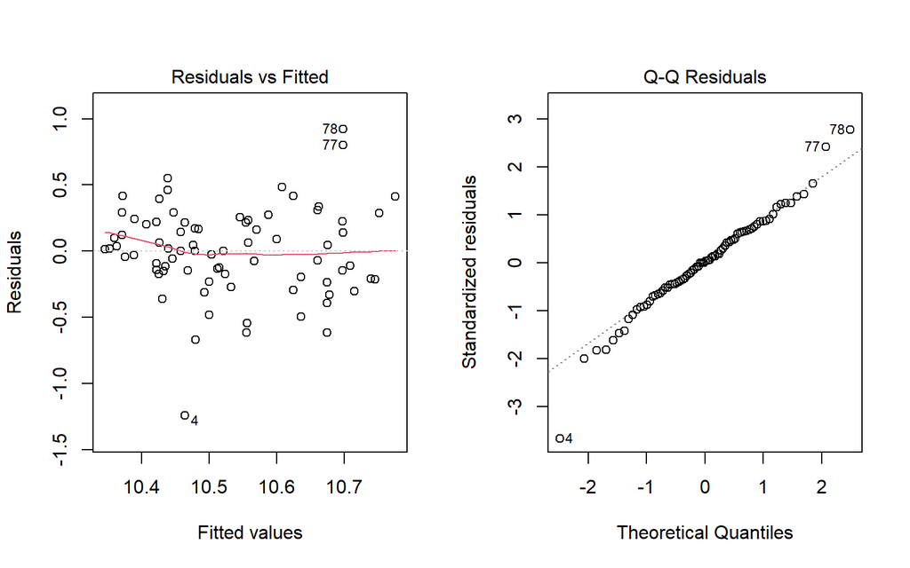

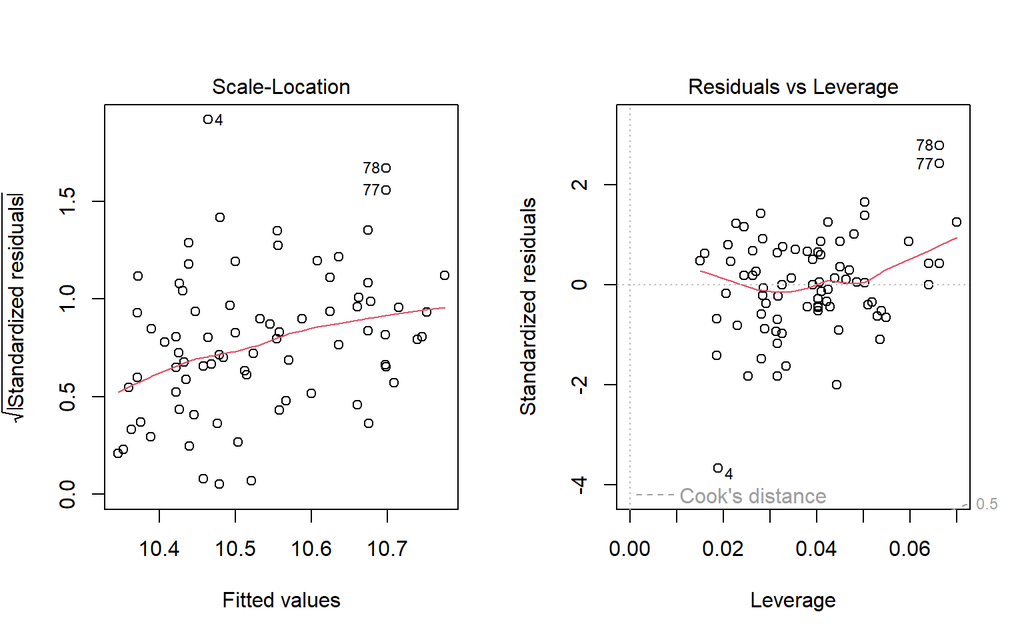

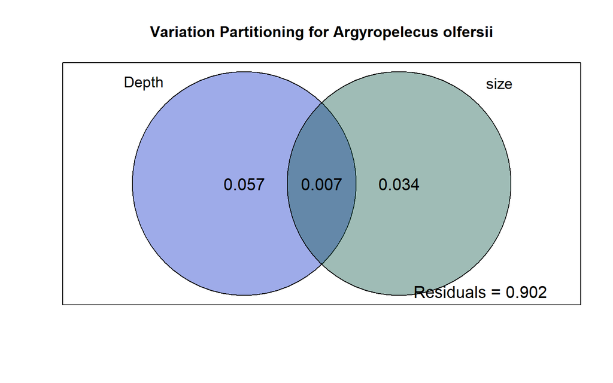

```
ANOVA (Depth-Size):
# A tibble: 2 × 5
  term        df Variance statistic p.value
  <chr>    <dbl>    <dbl>     <dbl>   <dbl>
1 Model        1   0.0152      4.92   0.029
2 Residual    61   0.189      NA     NA
ANOVA (Size-Depth):
# A tibble: 2 × 5
  term        df Variance statistic p.value
  <chr>    <dbl>    <dbl>     <dbl>   <dbl>
1 Model        1   0.0103      3.34   0.071
2 Residual    61   0.189      NA     NA
```

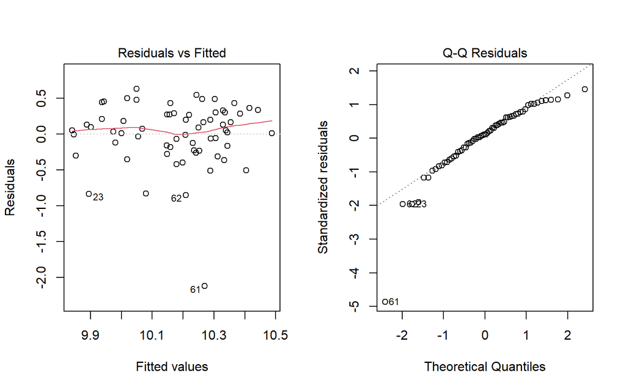

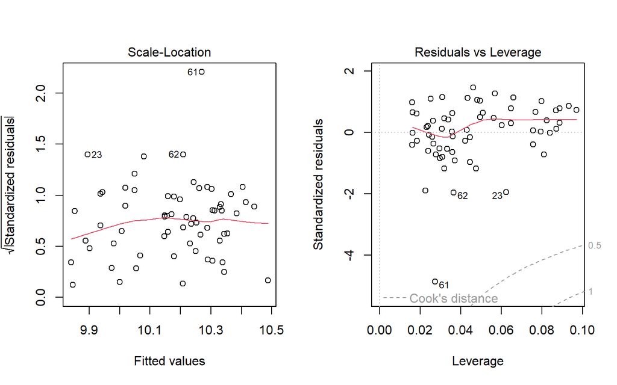

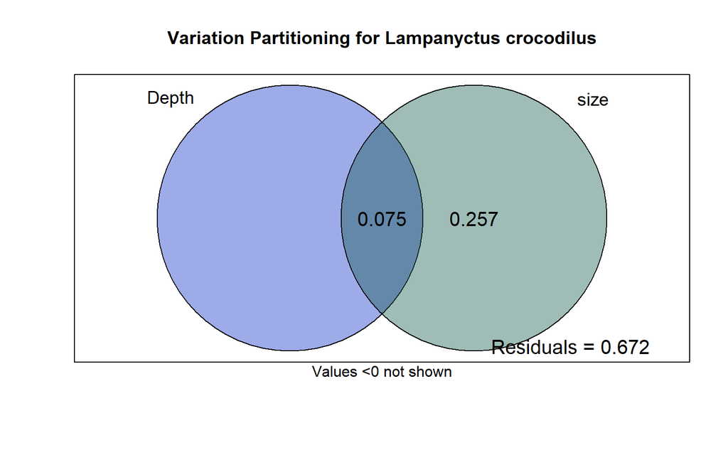

```
ANOVA (Depth-Size):
# A tibble: 2 × 5
  term        df Variance statistic p.value
  <chr>    <dbl>    <dbl>     <dbl>   <dbl>
1 Model        1 0.000170    0.0807    0.78
2 Residual   139 0.292      NA        NA
ANOVA (Size-Depth):
# A tibble: 2 × 5
  term        df Variance statistic p.value
  <chr>    <dbl>    <dbl>     <dbl>   <dbl>
1 Model        1    0.115      54.5   0.001
2 Residual   139    0.292      NA    NA
```

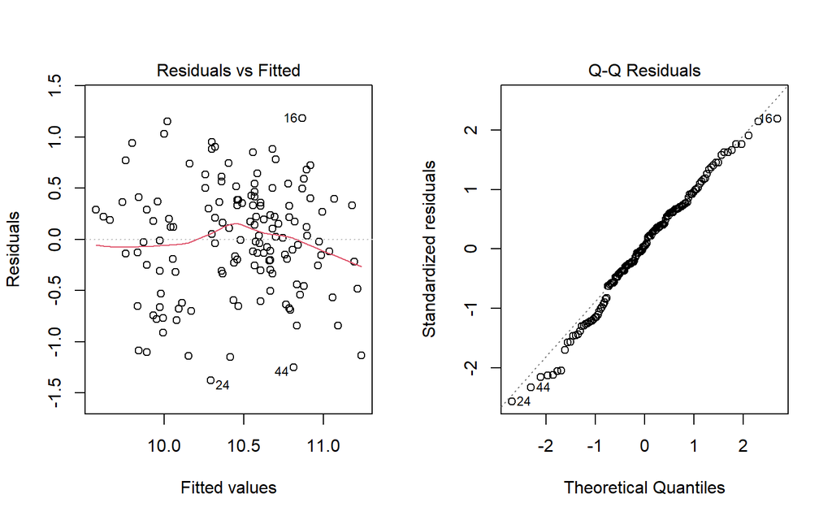

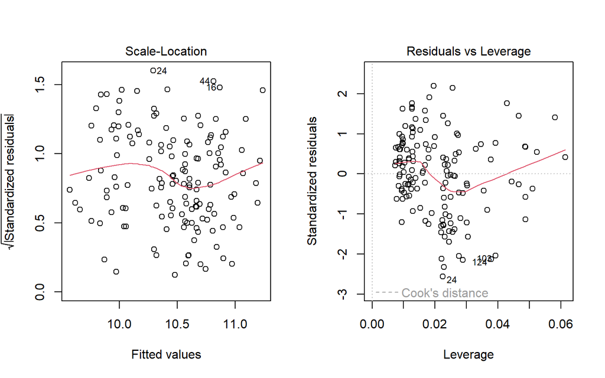

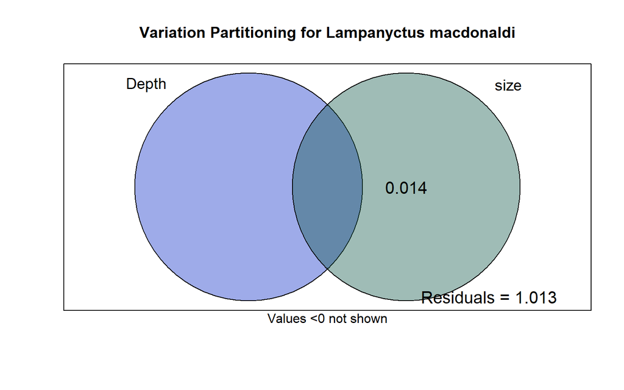

```
ANOVA (Depth-Size):
# A tibble: 2 × 5
  term        df Variance statistic p.value
  <chr>    <dbl>    <dbl>     <dbl>   <dbl>
1 Model        1  0.00254     0.578   0.491
2 Residual    20  0.0879     NA      NA
ANOVA (Size-Depth):
# A tibble: 2 × 5
  term        df Variance statistic p.value
  <chr>    <dbl>    <dbl>     <dbl>   <dbl>
1 Model        1  0.00572      1.30   0.255
2 Residual    20  0.0879      NA     NA
```

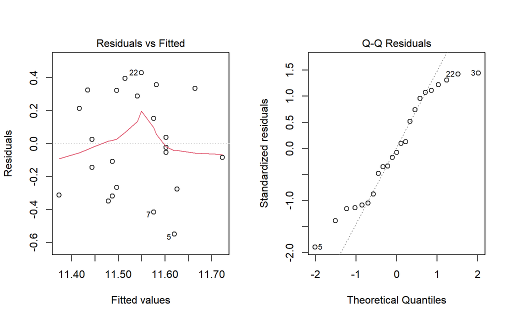

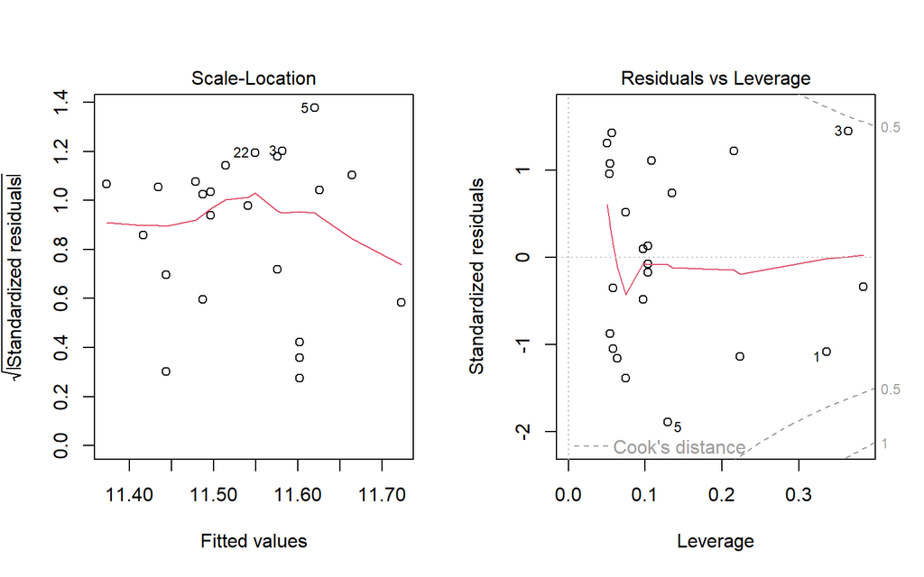

[18 more figures not shown]

```r
# S. boa and A. carbo not considered in this analysis due to small depth range sampled
varpart_data <- isotopic_dataset %>%
  filter(!species %in% c("Stomias boa", "Aphanopus carbo")) %>%
  arrange(species)

# List of species names
species_list <- unique(varpart_data$species)

# Initialize an empty list to store the results
result_list <- list()

# Initialize an empty data frame to store indfract values (variance of d15N values explained by depth and size)
indfract_df <-
  data.frame(species = character(0),
             indfract = numeric(0),
             variable = character(0))

# Loop through each species
for (species_name in species_list) {
  par(mfrow=c(1,1))

  # Filter the data for the current species
  species_data <- varpart_data %>%
    filter(species == species_name)

  # Perform variation partitioning analysis
  species_part <- vegan::varpart(species_data$d15N,
                                 ~ trawling_depth, ~ size, data = species_data)

  # Create the specified plot for the current species
  plot <- plot(
    species_part,
    Xnames = c("Depth", "size"),
    bg = c("#072AC8", "#0B5345"),
    alpha = 100,
    digits = 2,
    cex = 1.3
  )

  # Add a title to the plot
  title(main = paste("Variation Partitioning for", species_name))

  # Perform the significance testing
  rda1 <- vegan::rda(species_data$d15N,
                     species_data$trawling_depth,
                     species_data$size)
  rda2 <- vegan::rda(species_data$d15N,
                     species_data$size,
                     species_data$trawling_depth)
  anova1 <- vegan::anova.cca(rda1)
  anova2 <- vegan::anova.cca(rda2)

  # Check homogeneity of variances with residual plot
  model <- lm(d15N ~ trawling_depth + size, data = species_data)
  residuals <- residuals(model)

  # Store the results, and the significance testing in the list
  result_list[[species_name]] <-
    list(
      varpart_results = species_part,
      varpart_plot = plot,
      anova_depth_size = anova1,
      anova_size_depth = anova2,
      residuals = residuals
    )

  # Extract and store the indfract value (variance explained by each variable) in the data frame
  indfract_value <- species_part$part$indfract$Adj.R.squared
  indfract_df <-
    rbind(
      indfract_df,
      data.frame(
        species = species_name,
        indfract = indfract_value,
        variable = c("Depth only", "Size only", "Depth and size", "Residuals")
      )
    )

  # Print the significance testing results
  cat("ANOVA (Depth-Size):\n")
  print(broom::tidy(anova1))

  cat("ANOVA (Size-Depth):\n")
  print(broom::tidy(anova2))

  # Plot residual vs fitted
  par(mfrow = c(1, 2))
  cat("\n")
  plot(model)
}
```

## Variance partitionning summary

- compile information on a single plot for all species

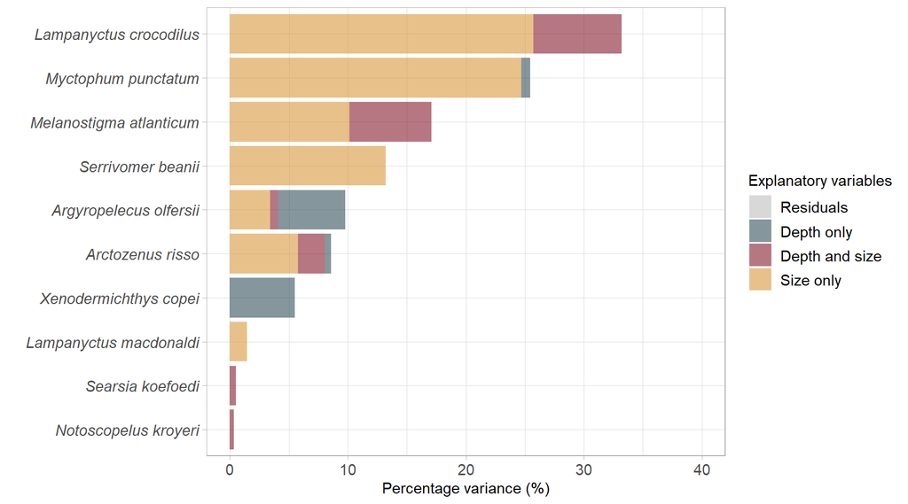

```r
#order according to the variance explained by each species
indfract_df$species <- factor(
  indfract_df$species,
  levels = c(
    "Notoscopelus kroyeri",
    "Searsia koefoedi",
    "Lampanyctus macdonaldi",
    "Xenodermichthys copei",
    "Arctozenus risso",
    "Argyropelecus olfersii",
    "Serrivomer beanii",
    "Melanostigma atlanticum",
    "Myctophum punctatum",
    "Lampanyctus crocodilus"
  )
)

# Percentage of variance for each variable + residuals
var_freq <- indfract_df %>%
  group_by(species) %>%
  mutate(freq = ((indfract * 100) / sum(indfract)))

# Order variable
var_freq$variable <- factor(var_freq$variable,
                            levels = c("Residuals", "Depth only", "Depth and size", "Size only"))


# plot
ggplot(var_freq , aes(fill=variable, y=freq, x=species)) +
  geom_bar(position="stack", stat="identity", alpha=0.6, linewidth=0.5)+
  scale_fill_manual(values = c( "grey","#33505C","#861D31","#D8973C"))+
  theme_light()+
  coord_flip()+
  ylim(c(0,40))+
  ylab("Percentage variance (%)")+
  xlab("")+
  theme(axis.text.y = element_text(face ="italic", size=11),
        axis.title = element_text(size=11),
        legend.text = element_text(size=11),
        legend.title = element_text(size=11),
        axis.text.x = element_text(size=11))+
  guides(fill=guide_legend(title="Explanatory variables"),
         color="none")
```

```r
# store the plot in the "figures" file in high resolution
ggsave("d15n_variability.png", path = "figures", dpi = 700, width = 8, height = 5)
```

# 4. Appendices

## Representativeness of sample sizes between the two data sets

- In order to compare the sizes of the species in the two data sets, a conversion from standard size to total size was carried out using conversion equations estimated in the laboratory by Tiphaine Chouvelon.

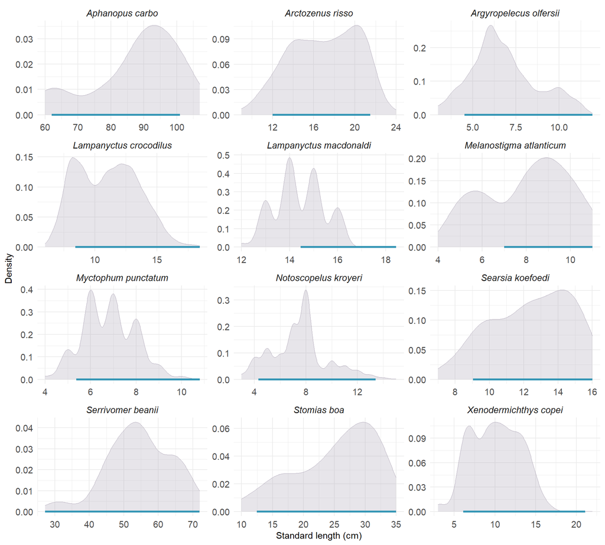

```r
# conversion standard length in total length for the isotope dataset (equations by Tiphaine Chouvelon)
isotopic_dataset_TL <- isotopic_dataset %>%
  mutate(
    total_length = case_when(
      species == "Aphanopus carbo" & size < 85 ~ size + 3,
      species == "Aphanopus carbo" & size > 85 ~ size + 5,
      species == "Arctozenus risso" ~ size + 1,
      species == "Argyropelecus olfersii" ~ (size + 0.7913) / 0.9039,
      species == "Lampanyctus crocodilus" ~ (size + 0.4754) / 0.8284,
      species == "Lampanyctus macdonaldi" ~ (size + 0.4754) / 0.8284,
      species == "Melanostigma atlanticum" ~ size,
      species == "Myctophum punctatum" ~ (size - 1.0381) / 0.7373,
      species == "Notoscopelus kroyeri" ~ (size + 0.2406) / 0.8903,
      species == "Searsia koefoedi" ~ (size - 0.7343) / 0.8593,
      species == "Serrivomer beanii" ~ (size + 0.6654) / 1.0053,
      species == "Stomias boa" ~ (size + 0.2633) / 0.9679,
      species == "Xenodermichthys copei" ~ (size + 0.0631) / 0.9266)) %>%
  select(species, total_length) %>%
  mutate(data_set = "isotopic dataset") %>%
  rename("size" = "total_length")

# formatting the trawling data set
trawling_dataset_comparaison <- trawling_dataset %>%
  select(species, size) %>%
  mutate(data_set = "trawling dataset")

# merge the two data frame
size_comparaison <-
  rbind(trawling_dataset_comparaison, isotopic_dataset_TL)

# Calculate the size range for each species in the isotopic dataset
size_ranges <- subset(size_comparaison, data_set == "isotopic dataset") %>%
  group_by(species) %>%
  summarize(min_size = min(size), max_size = max(size))

# plot
ggplot(subset(size_comparaison, data_set == "trawling dataset"), aes(x = size)) +
  geom_density(alpha = 0.3, linewidth = 0.3, fill = "#B0A8B9", col = "#B0A8B9") +
  facet_wrap(~species, scale = "free", ncol = 3) +
  theme_minimal() +
  theme(strip.text.x = element_text(size = 11, face = "italic"),
        axis.title = element_text(size = 11),
        axis.text = element_text(size = 11),
        legend.title = element_text(size = 11),
        legend.text = element_text(size = 11),
        panel.background = element_rect(fill = "white", colour = "white"),
        plot.background = element_rect(fill = "white", colour = "white")) +
  xlab("Standard length (cm)") +
  ylab("Density")+
  geom_segment(data = size_ranges,
               aes(x = min_size, xend = max_size, y = 0, yend = 0), color = "#3596B5", linewidth=1.2)
```

```r
ggsave("Appendix_1.png", path = "figures", dpi = 700, width = 9, height = 8)
```

## Test of temporal variability on $\delta$<sup>15</sup>N values

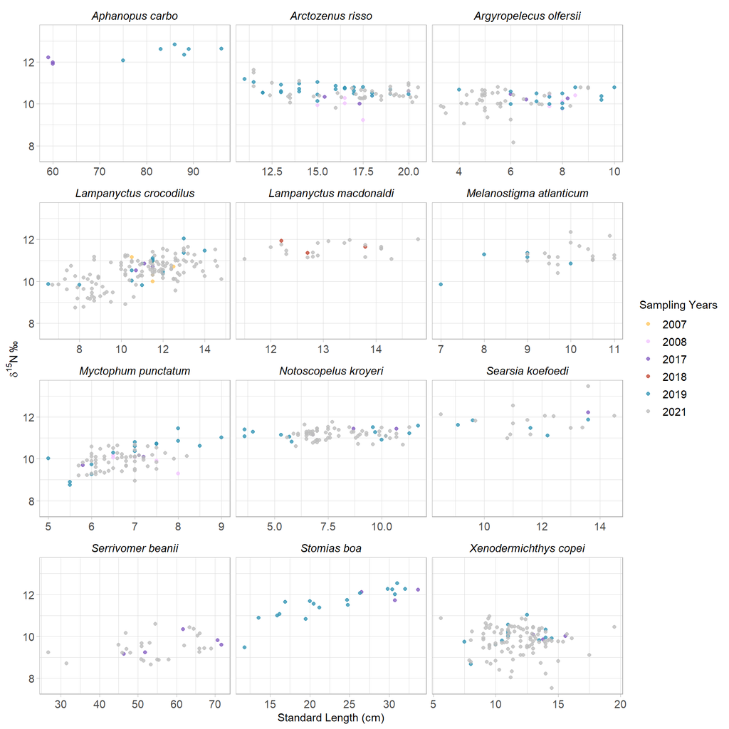

```r
# color for each sampling Years
col_Years <- c("#FFC75F", "#F3C5FF", "#845EC2", "#C34A36", "#3596B5", "grey")

# Years in discrete variable
isotopic_dataset$Years <- as.character(isotopic_dataset$Years)

# plot
ggplot(isotopic_dataset , aes(x=size, y=d15N))+
  geom_point (alpha=0.8, aes(col=Years), size=1.5) +
  scale_color_manual(values = col_Years)+
  facet_wrap(~species, scale="free_x", ncol=3)+
  xlab("Standard Length (cm)")+
  ylab(expression({delta}^15*N~'\u2030'))+
  theme_light()+
  labs(col= "Sampling Years")+
  theme(strip.text.x = element_text(size = 11, face = "italic", color = "black"),
        strip.background=element_rect(fill="white"),
        axis.title = element_text(size=11),
        axis.text =  element_text(size=11),
        legend.title = element_text(size=11),
        legend.text = element_text(size=11),
        panel.background = element_rect(fill = "white",colour = "white"),
        plot.background = element_rect(fill = "white",colour = "white"))
```

```r
#store the plot in the "figures" file in high resolution
ggsave("Appendix_2.png", path = "figures", dpi = 700, height = 8, width = 9)
```

## Non-significant size-depth relationships at species level

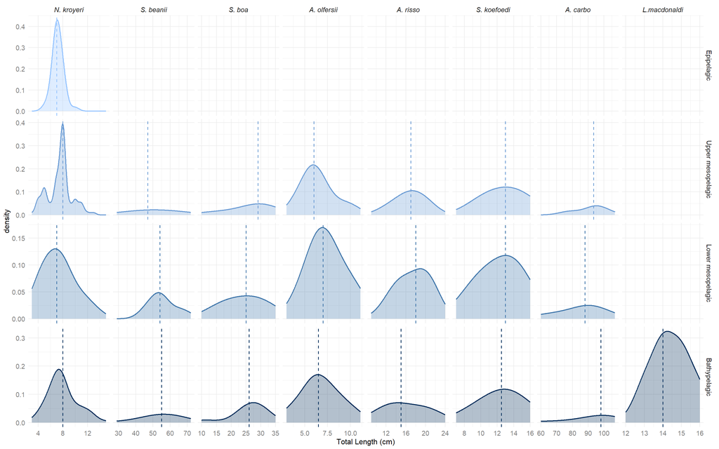

```r
# Selection of non-significant size-depth relationships
trawling_dataset_ns <-
  filter(
    trawling_dataset,
    species %in% c(
      "Arctozenus risso",
      "Lampanyctus macdonaldi",
      "Notoscopelus kroyeri",
      "Searsia koefoedi",
      "Serrivomer beanii",
      "Argyropelecus olfersii",
      "Stomias boa",
      "Aphanopus carbo"))

# order species
trawling_dataset_ns$species <- factor(
  trawling_dataset_ns$species,
  levels = c(
    "Notoscopelus kroyeri",
    "Serrivomer beanii",
    "Stomias boa",
    "Argyropelecus olfersii",
    "Arctozenus risso",
    "Searsia koefoedi",
    "Aphanopus carbo",
    "Lampanyctus macdonaldi"),
  labels = c(
    "N. kroyeri",
    "S. beanii",
    "S. boa",
    "A. olfersii",
    "A. risso",
    "S. koefoedi",
    "A. carbo",
    "L.macdonaldi"))

# Median depth
median_size_sp_ns <- trawling_dataset_ns %>%
  group_by(depth_layer, species) %>%
  summarise(median_size = median(size))

# plot
ggplot(trawling_dataset_ns, aes(x=size)) +
  geom_density(alpha=0.3, linewidth=0.8, adjust= 2, aes(fill= depth_layer, col= depth_layer))+
  scale_fill_manual(values = c("#93C3FF", "#6799D3","#3A72A8", "#002A58"))+
  scale_color_manual(values = c("#93C3FF", "#6799D3","#3A72A8", "#002A58"))+
  facet_grid(depth_layer~species, scale="free")+
  theme_minimal()+
  theme(strip.text.x = element_text(size=11, face="italic"),
        strip.text.y = element_text(size=11),
        axis.title = element_text(size=12),
        axis.text =  element_text(size=11, color= "grey50"),
        panel.background=element_rect(color="white"),
        plot.background = element_rect(fill = "white",colour = "white"),
        legend.title = element_text(size=12),
        legend.text = element_text(size=12))+
  guides(fill="none",col="none")+
  xlab("Total Length (cm)")+
  geom_vline(data =median_size_sp_ns, aes(xintercept = median_size, color=depth_layer),
             linewidth=0.6, linetype="dashed")
```

```r
# store the plot in the "figures" file in high resolution
ggsave("Appendix_3.png", path = "figures", dpi = 700, width = 9, height = 8)
```